# Bericht - Titanic Data Analyse

### **1. Übersicht über den Titanic-Datensatz**

```r
data <- read.csv("titanic_data.csv")
str(data)
```

```
## 'data.frame':    891 obs. of  12 variables:
##  $ PassengerId: int  1 2 3 4 5 6 7 8 9 10 ...
##  $ Survived   : int  0 1 1 1 0 0 0 0 1 1 ...
##  $ Pclass     : int  3 1 3 1 3 3 1 3 3 2 ...
##  $ Name       : chr  "Braund, Mr. Owen Harris" "Cumings, Mrs. John Bradley (Florence Briggs Thayer)" "Heikkinen, Miss. Laina" "Futrelle, Mrs. Jacques Heath (Lily May Peel)" ...
##  $ Sex        : chr  "male" "female" "female" "female" ...
##  $ Age        : num  22 38 26 35 35 NA 54 2 27 14 ...
##  $ SibSp      : int  1 1 0 1 0 0 0 3 0 1 ...
##  $ Parch      : int  0 0 0 0 0 0 0 1 2 0 ...
##  $ Ticket     : chr  "A/5 21171" "PC 17599" "STON/O2. 3101282" "113803" ...
##  $ Fare       : num  7.25 71.28 7.92 53.1 8.05 ...
##  $ Cabin      : chr  "" "C85" "" "C123" ...
##  $ Embarked   : chr  "S" "C" "S" "S" ...
```

```r
colSums(is.na(data))
```

```
## PassengerId    Survived      Pclass        Name         Sex         Age
##           0           0           0           0           0         177
##       SibSp       Parch      Ticket        Fare       Cabin    Embarked
##           0           0           0           0           0           0
```

Zunächst haben wir versucht, die Struktur des Titanic-Datensatzes mithilfe von R-Code zu analysieren. Die Ausgabe des Codes zeigt, dass der Datensatz 891 Zeilen und 12 Spalten umfasst, was 891 Passagieren mit 12 Merkmalen entspricht. Diese Merkmale sind: Passagier-ID, Überlebensstatus, Passagierklasse, Name, Geschlecht, Alter, Anzahl der Geschwister/Ehepartner an Bord, Anzahl der Eltern/Kinder an Bord, Ticketnummer, Ticketpreis, Kabine und Einschiffungshafen.

Es wurde festgestellt, dass 177 Werte für das Alter der Passagiere fehlen. Um diesem Problem zu begegnen, haben wir uns dazu entschieden, Passagiere mit fehlenden Altersangaben zu entfernen und uns ausschließlich auf die verbleibenden 714 Passagiere mit vollständigen Daten zu konzentrieren.

```
## 'data.frame':    714 obs. of  12 variables:
##  $ PassengerId: int  1 2 3 4 5 7 8 9 10 11 ...
##  $ Survived   : Factor w/ 2 levels "Died","Survived": 1 2 2 2 1 1 1 2 2 2 ...
##  $ Pclass     : Factor w/ 3 levels "1","2","3": 3 1 3 1 3 1 3 3 2 3 ...
##  $ Name       : chr  "Braund, Mr. Owen Harris" "Cumings, Mrs. John Bradley (Florence Briggs Thayer)" "Heikkinen, Miss. Laina" "Futrelle, Mrs. Jacques Heath (Lily May Peel)" ...
##  $ Sex        : Factor w/ 2 levels "female","male": 2 1 1 1 2 2 2 1 1 1 ...
##  $ Age        : int  22 38 26 35 35 54 2 27 14 4 ...
##  $ SibSp      : int  1 1 0 1 0 0 3 0 1 1 ...
##  $ Parch      : int  0 0 0 0 0 0 1 2 0 1 ...
##  $ Ticket     : chr  "A/5 21171" "PC 17599" "STON/O2. 3101282" "113803" ...
##  $ Fare       : num  7.25 71.28 7.92 53.1 8.05 ...
##  $ Cabin      : chr  "" "C85" "" "C123" ...
##  $ Embarked   : Factor w/ 4 levels "","C","Q","S": 4 2 4 4 4 4 4 4 2 4 ...
```

Basierend auf der Ausgabe von summary() erhalten wir einen detaillierten Einblick in die Struktur des Titanic-Datensatzes.

```r
summary(sub_data)
```

```
##   PassengerId        Survived   Pclass      Name               Sex
##  Min.   :  1.0   Died    :424   1:186   Length:714         female:261
##  1st Qu.:222.2   Survived:290   2:173   Class :character   male  :453
##  Median :445.0                  3:355   Mode  :character
##  Mean   :448.6
##  3rd Qu.:677.8
##  Max.   :891.0
##       Age            SibSp            Parch           Ticket
##  Min.   : 0.00   Min.   :0.0000   Min.   :0.0000   Length:714
##  1st Qu.:20.00   1st Qu.:0.0000   1st Qu.:0.0000   Class :character
##  Median :28.00   Median :0.0000   Median :0.0000   Mode  :character
##  Mean   :29.68   Mean   :0.5126   Mean   :0.4314
##  3rd Qu.:38.00   3rd Qu.:1.0000   3rd Qu.:1.0000
##  Max.   :80.00   Max.   :5.0000   Max.   :6.0000
##       Fare           Cabin           Embarked
##  Min.   :  0.00   Length:714          :  2
##  1st Qu.:  8.05   Class :character   C:130
##  Median : 15.74   Mode  :character   Q: 28
##  Mean   : 34.69                      S:554
##  3rd Qu.: 33.38
##  Max.   :512.33
```

Die Analyse der Titanic-Datenausgabe gibt uns einen umfassenden Einblick in die Charakteristika der Passagiere:

- Von den insgesamt 714 Passagieren sind 424 verstorben, während 290 überlebt haben, was 40,6 % der Passagiere entspricht. Das bedeutet, dass mehr Menschen sterben als überlebt haben.
- Die Verteilung der Passagierklassen zeigt, dass 186 zur Klasse 1, 173 zur Klasse 2 und 355 zur Klasse 3 gehören. Die erste Klasse ist eine VIP-Klasse mit den wohlhabendsten Passagieren des Schiffes, darunter prominente Mitglieder der Oberschicht, Geschäftsleute, Politiker, hochrangige Soldaten, Entertainer, Prominente und Profisportler. Zu den Passagieren der zweiten Klasse gehörten hauptsächlich Reisende der Mittelklasse, darunter Professoren, Autoren und Touristen. Passagiere der dritten Klasse waren hauptsächlich Einwanderer in die Vereinigten Staaten und Kanada, und die meisten Menschen sind hier.
- Hinsichtlich des Geschlechts sind 261 Passagiere weiblich und 453 männlich, was bedeutet, dass 36,6 % der Passagiere weiblich sind.
- Das Alter der Passagiere variiert zwischen 0 und 80 Jahren, mit einem Durchschnittsalter von 29,68 Jahren.
- Die Anzahl der Geschwister/Ehepartner an Bord (SibSp) und der Eltern/Kinder an Bord (Parch) zeigt Variationen, wobei die durchschnittlichen Werte bei 0,51 bzw. 0,43 liegen.
- Der Fahrpreis (Fare) erstreckt sich von 0 bis 512,33, wobei der durchschnittliche Preis bei 34,69 liegt.
- Die Einschiffungshäfen sind in den Kategorien “C”, “Q” und “S” verteilt, wobei “S” mit 554 Passagieren am häufigsten ist.

Diese Daten wurden auf der Seite „Overview“ visualisiert und hier können Benutzer verschiedene Kriterien wie Passagierklasse, Geschlecht, Einschiffungshafen, Alter, Ticketpreis sowie Passagiere mit Eltern/Kindern oder Geschwistern/Ehepartnern an Bord auswählen. Anschließend wurden Passagiere mit diesen Merkmalen in Tabellen ausgedruckt und ihre Überlebensrate in einem Kreisdiagramm visualisiert. Die Kabineninformationen, die Passagier-ID und das Ticket haben keinen großen Einfluss auf die Überlebenschancen der Passagiere, sodass sie nicht berücksichtigt werden.

### **2. Die Überlebenschancen der Passagiere nach jeder Merkmale**

Um die Überlebensrate von Passagieren zu untersuchen, wurden verschiedene Arten von Diagrammen verwendet, die uns bei der Visualisierung der Daten helfen. Für Merkmale Geschlecht wurde das Mosaikplot verwendet, während die meisten anderen Merkmale im Balkendiagramm oder Histogramm visualisiert wurden. Darüber hinaus wurde der Boxplot verwendet, um die Verteilung des Ticketpreises darzustellen.

#### **2.1. Sex**

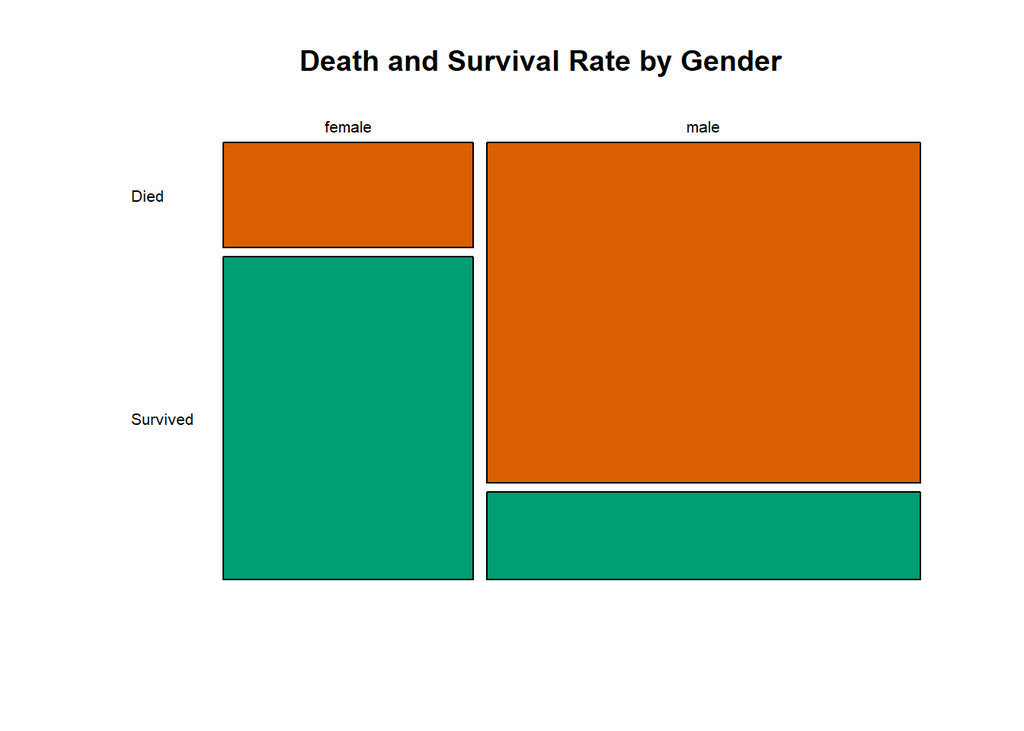

#### **2.2. Age**

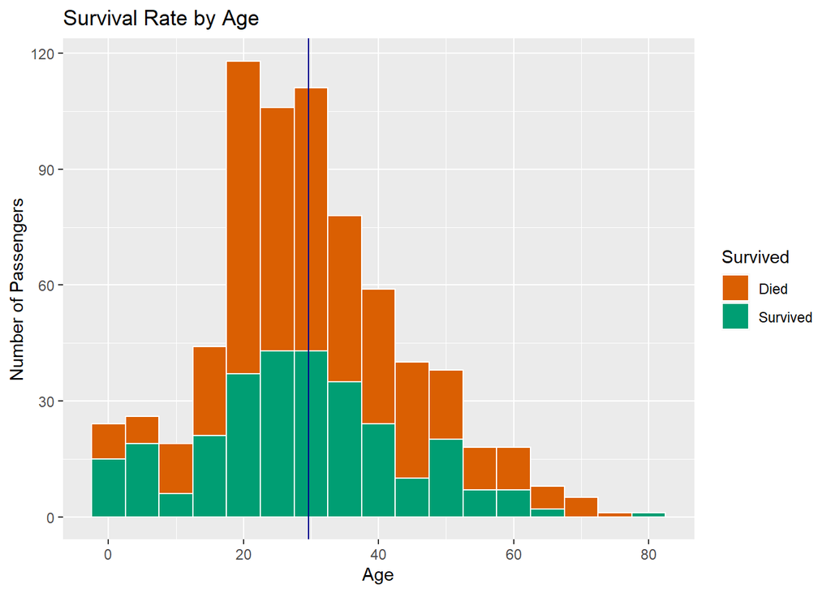

#### **2.3. PClass**

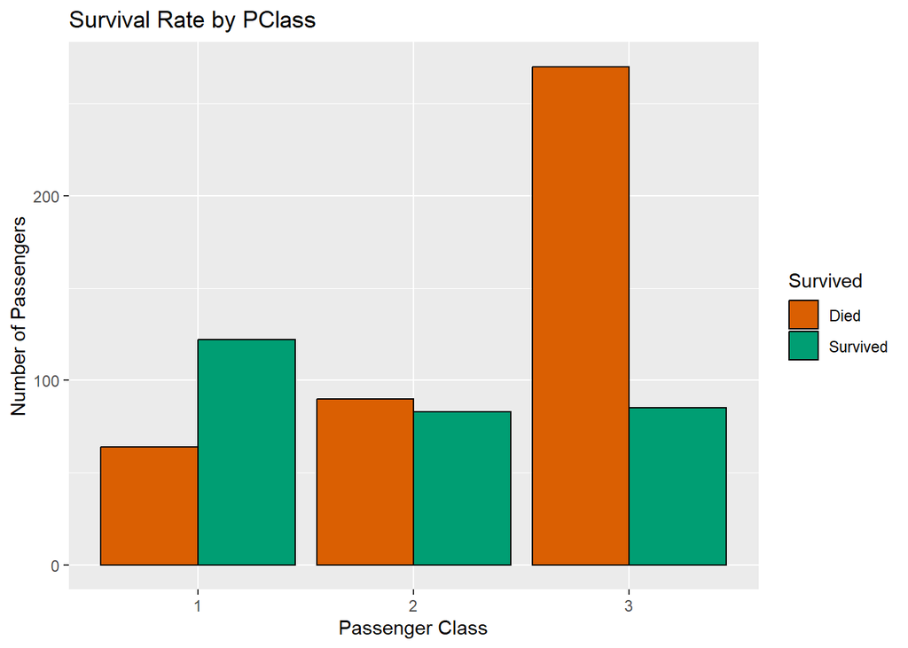

Die Zugehörigkeit zur Passagierklasse scheint einen Einfluss auf Leben und Tod zu haben. Anhand der vorliegenden Balkendiagramm stammen die überlebenden Passagiere vorwiegend aus der ersten Klasse, während die Verstorbenen größtenteils der dritten Klasse angehörten, obwohl die Anzahl der Passagiere in der dritten Klasse höher war als die in der ersten und zweiten Klasse. Dies bedeutet, dass Personen der ersten Klasse während des Evakuierungsprozesses möglicherweise eine höhere Priorität erhielten als diejenigen der dritten Klasse.

#### **2.4. SibSp**

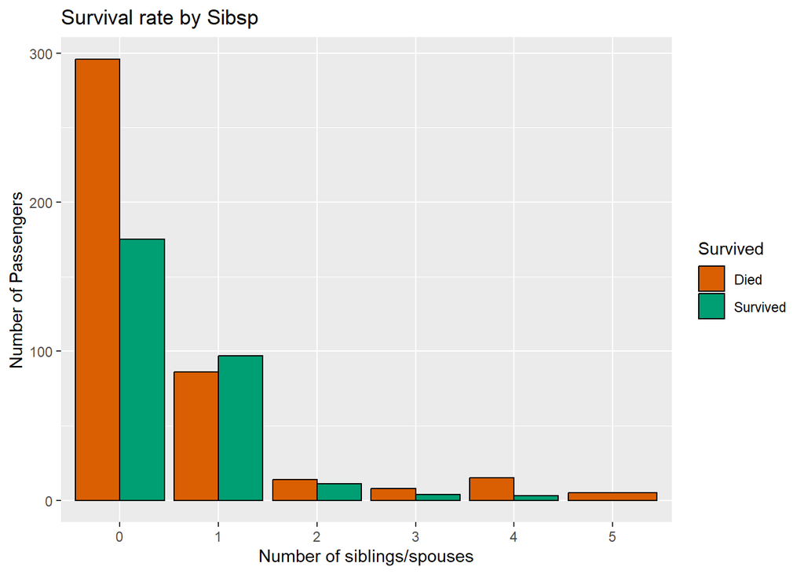

Die vorliegende Balkendiagramm verdeutlicht, dass mehr als 90 % der Personen entweder allein reisten oder in Begleitung eines Geschwisters oder Ehepartners waren. Interessanterweise wiesen Passagiere, die in Begleitung eines Geschwisters oder Ehepartners reisten, eine höhere Überlebensrate auf. Jedoch sanken die Überlebenschancen erheblich, wenn jemand mit zwei oder mehr Geschwistern oder Ehepartner reiste. Bedauerlicherweise überlebte kein Passagier, bei dem die Anzahl der Geschwister oder Ehepartner (SibSp) größer als 4 war.

#### **2.5. Parch**

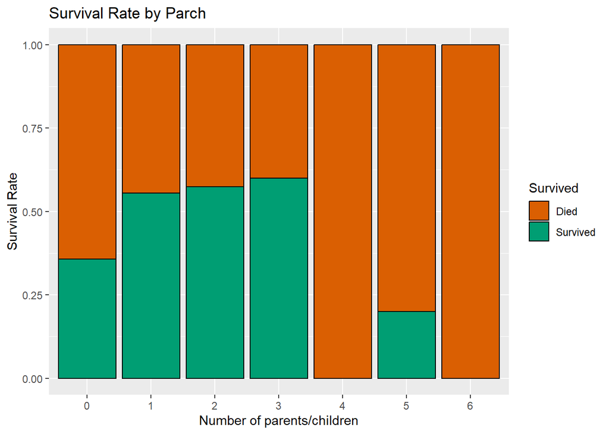

Basierend auf dem Diagramm oben hat eine höhere Anzahl von Passagieren, die mit ein bis drei Eltern oder Kindern reisten, überlebt im Vergleich zu Personen, die alleine reisten oder vier oder mehr Eltern/Kindern hatten. Allerdings überlebten fast keine Passagiere mit Parch > 3.

Anhand der Statistken von Parch und SibSp haben Passagiere mit wenigen Familienangehörigen höhere Überlebenschance.

#### **2.6. Embarked**

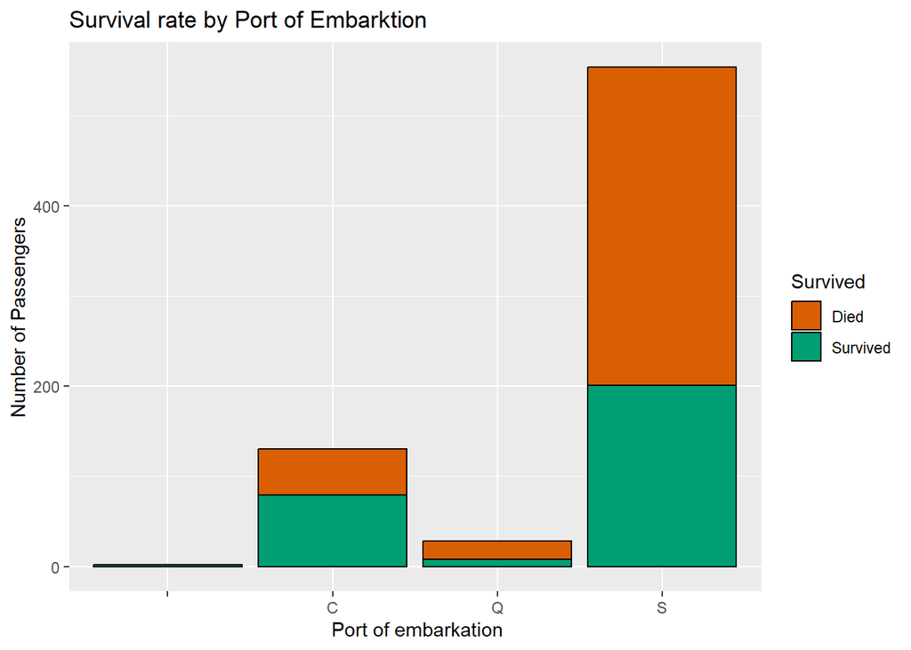

“Embarked” weist zwei fehlende Werte auf und wird aber als vorhandene Daten mit leerem Wert angezeigt. Es gibt drei mögliche Werte für “Embark” – Southampton, Cherbourg und Queenstown. Die Mehrheit der Passagiere schiffte sich in Southampton ein. Etwa 20% stiegen in Cherbourg an Bord, während der Rest in Queenstown einschiffte. Allerdings scheinen Passagiere, die in Cherbourg an Bord gingen, glücklicher zu sein, da mehr als die Hälfte von ihnen überlebte. Im Gegensatz dazu überlebten nur 33 Prozent der Passagiere, die in Southampton an Bord gingen. Ähnliche Situtaion wurden bei den Passagieren beobachtet, die das Schiff in Queenstown bestiegen.

#### **2.7. Fare**

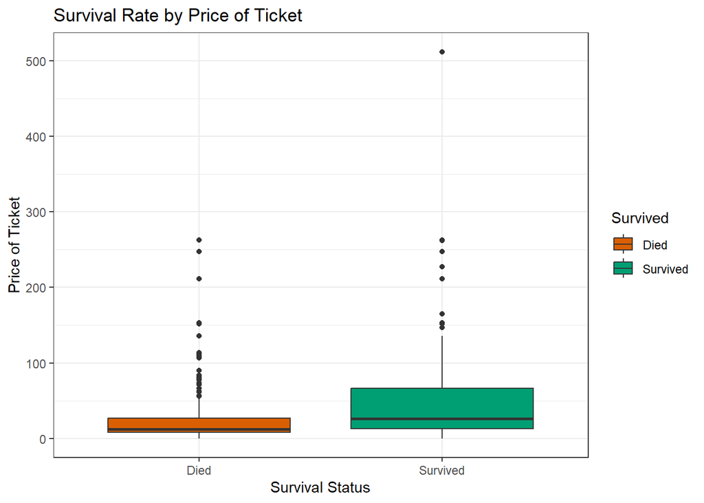

### **3. Die Überlebenschancen der Passagiere nach gemischten Merkmalen**

#### **3.1.** Überlebens- und Todesverteilung nach Age und PClass

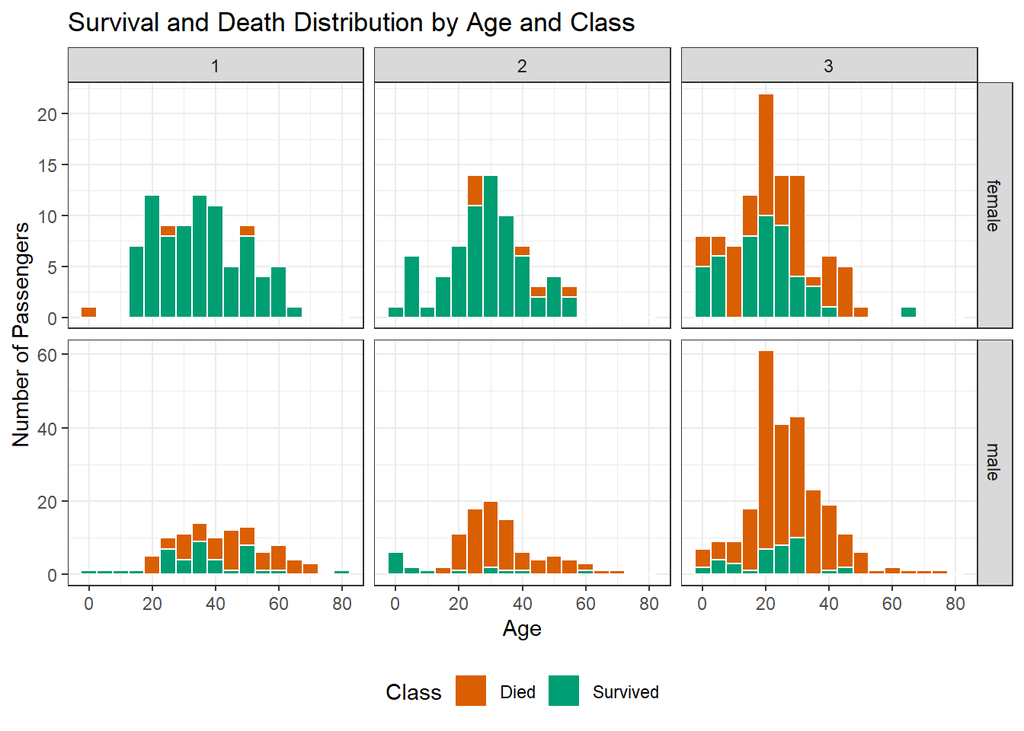

Anhand des obigen Diagramms zeigt, dass Frauen im Vergleich zu Männern häufiger überlebten, insbesondere unter Passagieren der ersten und zweiten Klasse. Bei Frauen in der dritten Klasse ist die Überlebensrate für jüngere Passagiere höher. Im Gegensatz dazu ist die Überlebensrate für männliche Passagiere im Allgemeinen gering, wobei männliche Passagiere in der dritten Klasse die höchste Sterblichkeitsrate aufweisen. Nur Kinder und Jugendliche haben eine höhere Überlebenschance haben.

#### **3.2.** Altersverteilung der Passagiere nach PClass und Sex

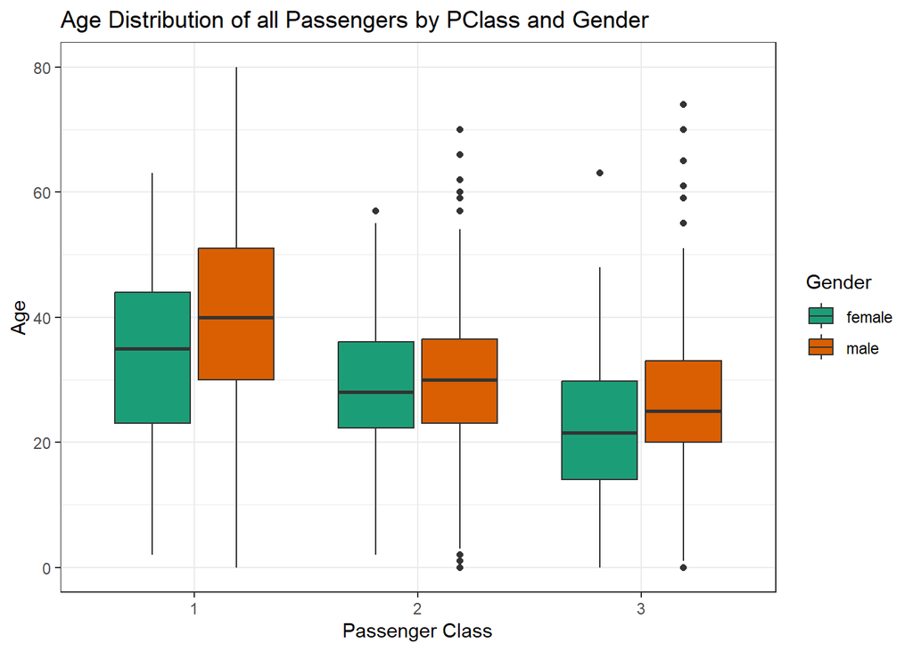

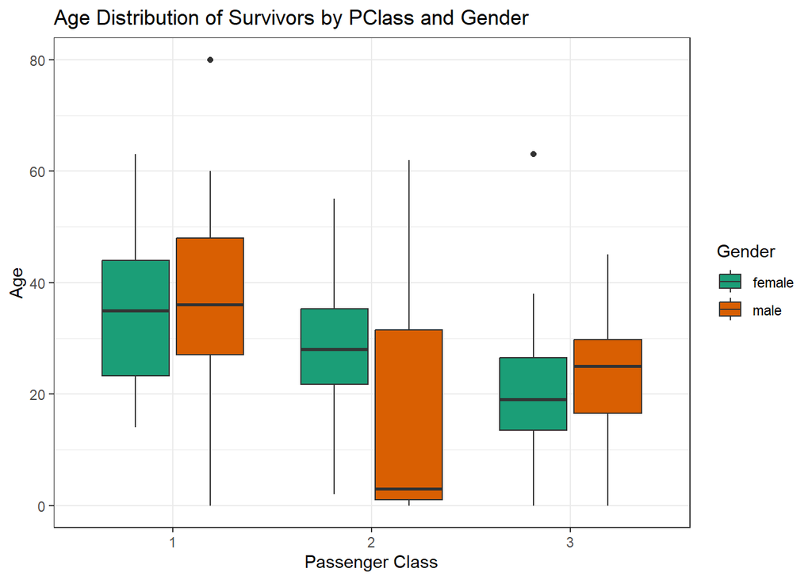

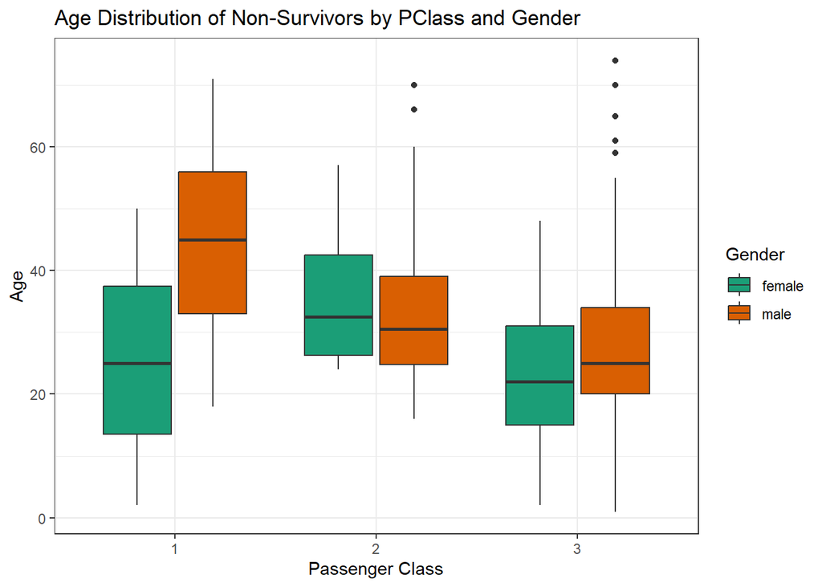

### **4. Fazit**

Die Überlebenschancen der Titanic-Passagiere wurden von verschiedenen Merkmalen beeinflusst, wobei Alter, Kabinenklasse und Geschlecht die stärksten Zusammenhänge aufwiesen.

Bestimmte Altersgruppen hatten höhere Überlebenschancen, wobei Kinder und Jugendliche tendenziell bessere Chancen hatten als ältere Passagiere. Zudem wiesen Passagiere der ersten Klasse eine höhere Überlebensrate auf als die der dritten Klasse, und Frauen hatten deutlich höhere Überlebenschancen als Männer.

Die Reise mit einem Geschwister oder Ehepartner erhöhte die Überlebenschancen, während das Reisen mit mehr als zwei Geschwistern oder Ehepartnern die Chancen verringerte. Höhere Fahrpreise korrelierten ebenfalls mit besseren Überlebenschancen.

Die Kombination von Merkmalen wie Alter, Kabinenklasse und Geschlecht haben signifikante Bedeutung. Frauen, besonders aus den höheren Klassen, sowie Kinder und Jugendliche gehörten zu den Gruppen mit höheren Überlebenschancen. Insbesondere hatten frauen der ersten Klasse die höchsten Überlebenschancen, während männliche Passagiere der dritten Klasse eher die niedrigsten Überlebensraten aufwiesen.